# Distributions

```r
library(prob)
library(tidyverse)
```

# Distributions

### A rigourous definition

A distribution is a list of all of the possible outcomes of a random variable along with either their corresponding frequency or probability values (we would speak of the frequency distribution or probability distribution respectively).

### Less rigourous

Defined either way, the distribution gives insight into how likely or how common the various outcomes are.

```r
three_coins <- tosscoin(3)

three_coins
```

| toss1 | toss2 | toss3 |
| --- | --- | --- |
| H | H | H |
| T | H | H |
| H | T | H |
| T | T | H |
| H | H | T |
| T | H | T |
| H | T | T |
| T | T | T |

#### Task - 2 mins what is the probability of each of the eight outcomes if all of the coins are unbiased? What does ‘unbiased’ mean here? Why is it important that each of the coins are unbiased in this calculation?

Distribution 1: Uniform Distribution

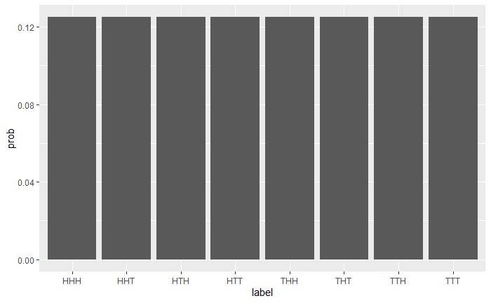

```r
three_coins_p <-  three_coins %>%
  mutate(label = str_c(toss1, toss2, toss3)) %>%
  mutate(prob = 1/n())

three_coins_p %>%
  ggplot() +
  geom_col(aes(x = label, y = prob))
```

Uniform Distribution -

All the bars are the same height, indicating the probability of each outcome is the same

A bit more intrtrsting …

What are the probabilities of getting 0 1, 2 or 3 heads on the toss of three unbiased coins?

```r
three_coins_p %>%
  mutate(n_heads = str_count(label, "H")) %>%
  group_by(n_heads) %>%
  summarise(prob = sum(prob))
```

| n_heads | prob |
| --- | --- |
| 0 | 0.125 |
| 1 | 0.375 |
| 2 | 0.375 |
| 3 | 0.125 |

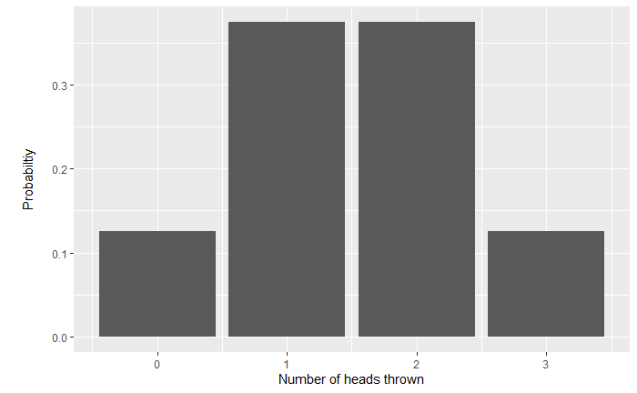

```r
three_coins_p %>%
  mutate(n_heads = str_count(label, "H")) %>%
  group_by(n_heads) %>%
  summarise(prob = sum(prob)) %>%
  ggplot() +
  geom_col(aes(x = n_heads, y = prob)) +
  xlab("Number of heads thrown") +
  ylab("\n Probabiltiy \n")
```

Distribution is no longer uniform (bars havediffering hights)

Distribution is still discrete (bar-able)

General Properties of Discrete Distributions

x-axis = outcomes y-axis = probaility or frequency THE PROBABILITIES MUST SUM TO 1

If you stacked all the bars on top of each other, the y-axis would read 1.